# AeroFit_treadMill_Case_study

## Executive Summary

This case study analyzes customer purchasing behavior for AeroFit treadmills. The analysis shows that **income, fitness level, and usage intensity** are the primary drivers of product selection, while age has minimal influence.

KP781 serves a distinct premium segment consisting of high-income, high-fitness, and high-usage customers, whereas KP281 and KP481 cater to mass-market and mid-tier users with similar behavioral patterns.

```python
import pandas as pd
import numpy as np
import matplotlib.pyplot as plt
import seaborn as sns
```

```python
# Problem Statement (AeroFit):
# AeroFit wants to understand who buys which treadmill model so they can:

# Target the right customers

# Improve marketing & sales strategy

# Recommend products better

# Goal of Analysis:
# Create customer profiles for each treadmill product.
```

```python
df = pd.read_csv(r"C:\Users\shubh\Downloads\aerofit_treadmill.csv")
df.head()
```

|  | Product | Age | Gender | Education | MaritalStatus | Usage | Fitness | Income | Miles |
| --- | --- | --- | --- | --- | --- | --- | --- | --- | --- |
| 0 | KP281 | 18 | Male | 14 | Single | 3 | 4 | 29562 | 112 |
| 1 | KP281 | 19 | Male | 15 | Single | 2 | 3 | 31836 | 75 |
| 2 | KP281 | 19 | Female | 14 | Partnered | 4 | 3 | 30699 | 66 |
| 3 | KP281 | 19 | Male | 12 | Single | 3 | 3 | 32973 | 85 |
| 4 | KP281 | 20 | Male | 13 | Partnered | 4 | 2 | 35247 | 47 |

```python
df.shape
```

```
(180, 9)
```

**Insight:**  
The dataset contains 180 records with no missing values, making it suitable for analysis without additional cleaning.

```python
df.info()
# Checked dataset shape and structure

# Verified data types and null values

# Reviewed summary statistics to understand overall distributions
```

```
<class 'pandas.core.frame.DataFrame'>
RangeIndex: 180 entries, 0 to 179
Data columns (total 9 columns):
 #   Column         Non-Null Count  Dtype
---  ------         --------------  -----
 0   Product        180 non-null    object
 1   Age            180 non-null    int64
 2   Gender         180 non-null    object
 3   Education      180 non-null    int64
 4   MaritalStatus  180 non-null    object
 5   Usage          180 non-null    int64
 6   Fitness        180 non-null    int64
 7   Income         180 non-null    int64
 8   Miles          180 non-null    int64
dtypes: int64(6), object(3)
memory usage: 12.8+ KB
```

```python
df.describe()
```

|  | Age | Education | Usage | Fitness | Income | Miles |
| --- | --- | --- | --- | --- | --- | --- |
| count | 180.000000 | 180.000000 | 180.000000 | 180.000000 | 180.000000 | 180.000000 |
| mean | 28.788889 | 15.572222 | 3.455556 | 3.311111 | 53719.577778 | 103.194444 |
| std | 6.943498 | 1.617055 | 1.084797 | 0.958869 | 16506.684226 | 51.863605 |
| min | 18.000000 | 12.000000 | 2.000000 | 1.000000 | 29562.000000 | 21.000000 |
| 25% | 24.000000 | 14.000000 | 3.000000 | 3.000000 | 44058.750000 | 66.000000 |
| 50% | 26.000000 | 16.000000 | 3.000000 | 3.000000 | 50596.500000 | 94.000000 |
| 75% | 33.000000 | 16.000000 | 4.000000 | 4.000000 | 58668.000000 | 114.750000 |
| max | 50.000000 | 21.000000 | 7.000000 | 5.000000 | 104581.000000 | 360.000000 |

```python
# which product sell the most
# KP281: Highest sales volume

# KP481: Moderate sales

# KP781: Lowest volume
# KP281 is the mass-market entry-level product, while KP781 is a niche premium product.
df["Product"].value_counts()
```

```
Product
KP281    80
KP481    60
KP781    40
Name: count, dtype: int64
```

```python
# who is buying each product
#  gender distribution by product
# KP281 & KP481: Gender-balanced
# KP781: Strong male dominance
# Premium treadmills attract more performance-oriented male users.
pd.crosstab(df["Product"],df["Gender"], normalize = "index")*100
```

| Gender Product | Female | Male |
| --- | --- | --- |
| KP281 | 50.000000 | 50.000000 |
| KP481 | 48.333333 | 51.666667 |
| KP781 | 17.500000 | 82.500000 |

```python
df.groupby(['Product', 'Gender']).size()
```

```
Product  Gender
KP281    Female    40
         Male      40
KP481    Female    29
         Male      31
KP781    Female     7
         Male      33
dtype: int64
```

```python
# age distribution by product
df.groupby('Product')['Age'].describe()
# Mean age across all products ≈ late 20s

# No major age-based differentiation
# Insight:
# Age is not a strong driver of product choice.
```

| Product | count | mean | std | min | 25% | 50% | 75% | max |
| --- | --- | --- | --- | --- | --- | --- | --- | --- |
| KP281 | 80.0 | 28.55 | 7.221452 | 18.0 | 23.00 | 26.0 | 33.00 | 50.0 |
| KP481 | 60.0 | 28.90 | 6.645248 | 19.0 | 24.00 | 26.0 | 33.25 | 48.0 |
| KP781 | 40.0 | 29.10 | 6.971738 | 22.0 | 24.75 | 27.0 | 30.25 | 48.0 |

```python
# income vs product
df.groupby("Product")['Income'].describe()
# KP281 & KP481: Overlapping income ranges

# KP781: Significantly higher income levels

# Insight:
# Income is a key differentiator, especially for KP781.
```

| Product | count | mean | std | min | 25% | 50% | 75% | max |
| --- | --- | --- | --- | --- | --- | --- | --- | --- |
| KP281 | 80.0 | 46418.025 | 9075.783190 | 29562.0 | 38658.00 | 46617.0 | 53439.0 | 68220.0 |
| KP481 | 60.0 | 48973.650 | 8653.989388 | 31836.0 | 44911.50 | 49459.5 | 53439.0 | 67083.0 |
| KP781 | 40.0 | 75441.575 | 18505.836720 | 48556.0 | 58204.75 | 76568.5 | 90886.0 | 104581.0 |

```python
# fitneess level vs product
df.groupby("Product")["Fitness"].describe()
# KP281 & KP481: Average fitness levels (mostly 3)

# KP781: High fitness levels (4–5)

# Insight:
# KP781 is bought by customers who are already fit, not beginners.
```

| Product | count | mean | std | min | 25% | 50% | 75% | max |
| --- | --- | --- | --- | --- | --- | --- | --- | --- |
| KP281 | 80.0 | 2.9625 | 0.664540 | 1.0 | 3.0 | 3.0 | 3.0 | 5.0 |
| KP481 | 60.0 | 2.9000 | 0.629770 | 1.0 | 3.0 | 3.0 | 3.0 | 4.0 |
| KP781 | 40.0 | 4.6250 | 0.667467 | 3.0 | 4.0 | 5.0 | 5.0 | 5.0 |

```python
df.groupby('Product')['Usage'].describe()
# KP781 users show much higher usage intensity

# KP281 & KP481 users have similar, moderate usage

Insight:
# KP781 customers are serious and consistent users, validating the premium positioning.
```

[output not shown]

```python
df.groupby('Product')['Miles'].describe()
# KP781 users show much higher usage intensity

# KP281 & KP481 users have similar, moderate usage

Insight:
# KP781 customers are serious and consistent users, validating the premium positioning.
```

| Product | count | mean | std | min | 25% | 50% | 75% | max |
| --- | --- | --- | --- | --- | --- | --- | --- | --- |
| KP281 | 80.0 | 82.787500 | 28.874102 | 38.0 | 66.0 | 85.0 | 94.0 | 188.0 |
| KP481 | 60.0 | 87.933333 | 33.263135 | 21.0 | 64.0 | 85.0 | 106.0 | 212.0 |
| KP781 | 40.0 | 166.900000 | 60.066544 | 80.0 | 120.0 | 160.0 | 200.0 | 360.0 |

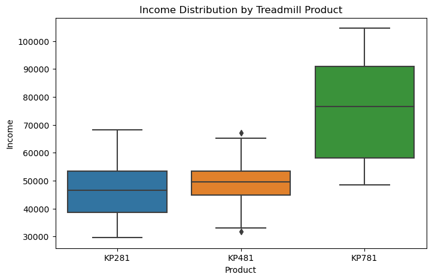

```python
# Data visualizations
import seaborn as sns
import matplotlib.pyplot as plt

plt.figure(figsize=(8,5))

sns.boxplot(x = "Product",y = "Income" ,data = df)

plt.title("Income Distribution by Treadmill Product")
plt.xlabel("Product")
plt.ylabel("Income")
plt.show()
# Boxplots were used to validate:

# Income differences across products

# Fitness level concentration

# Usage intensity patterns

# Visual analysis strongly supported all numerical findings.
```

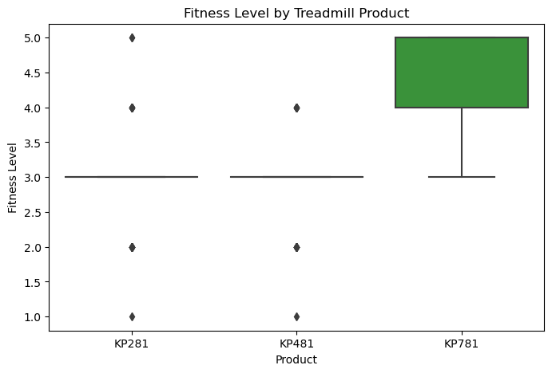

```python
# Fitness vs product
plt.figure(figsize=(8,5))
sns.boxplot(x = "Product",y = "Fitness" ,data = df)


plt.title("Fitness Level by Treadmill Product")
plt.xlabel("Product")
plt.ylabel("Fitness Level")
plt.show()
```

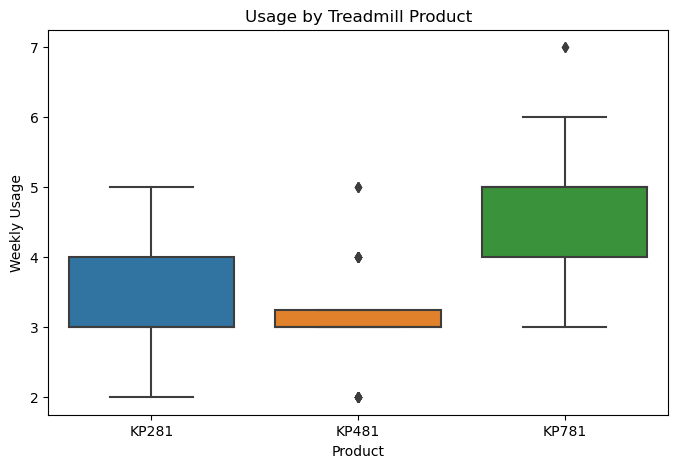

```python
plt.figure(figsize=(8,5))
sns.boxplot(x = "Product",y = "Usage",data = df)
plt.title("Usage by Treadmill Product")
plt.xlabel("Product")
plt.ylabel("Weekly Usage")
plt.show()
```

```python
# Final Customer Personas
# 🟢 KP281 – Entry-Level / Beginner Segment

# Balanced gender

# Mid-income customers

# Average fitness

# Moderate usage

# Goal: Start or maintain basic fitness

# 🟡 KP481 – Mid-Level / Regular Users

# Slightly higher income than KP281

# Similar fitness and usage patterns

# Acts as a transition product

# 🔴 KP781 – Premium / Performance Segment

# Predominantly male

# High-income customers

# High fitness levels

# Very high usage intensity

# Goal: Performance and endurance training
```

## Final Business Recommendation

Product choice at AeroFit is primarily driven by income, fitness level, and usage intensity rather than age.

- KP281 should be marketed as an entry-level treadmill for beginners.
- KP481 should be positioned as a comfort-oriented upgrade.
- KP781 should maintain premium pricing and target performance-focused users.